# Homework 3

Hanna Szczerbińska

## Source visualisation

[figure not shown]

Source visualisation, published on Oct 22nd.

The source visualisation shows the voter turnout in Travis County, TX on the 1st day of Early Voting in US presidential elections across the years. It has been published on X.com by Dyana Limon-Mercado (serving as the Travis County Clerk) on 22nd Oct 2024.

link: https://x.com/TravisCoClerk/status/1848542368229720302/photo/2

I will be focusing on improving the following aspects of this visualisation:  
- alignment with the Y axis (on the original graph, the number on the first column is different from its height as read from the Y axis)  
- ordering of columns along the X axis (on the original graphic they’re put in an anti-chronological order, making the chart less readable by suggesting a drop over time while the opposite is true)  
- color scheme choice (in graphics related to US politics, red and blue shouldn’t be used unless they refer to Republicans and Democrats, as they suggest party alignment)  
- moving the legend onto X axis for improved readability (and to remove the need for different coloured columns)

## Improved visualisation

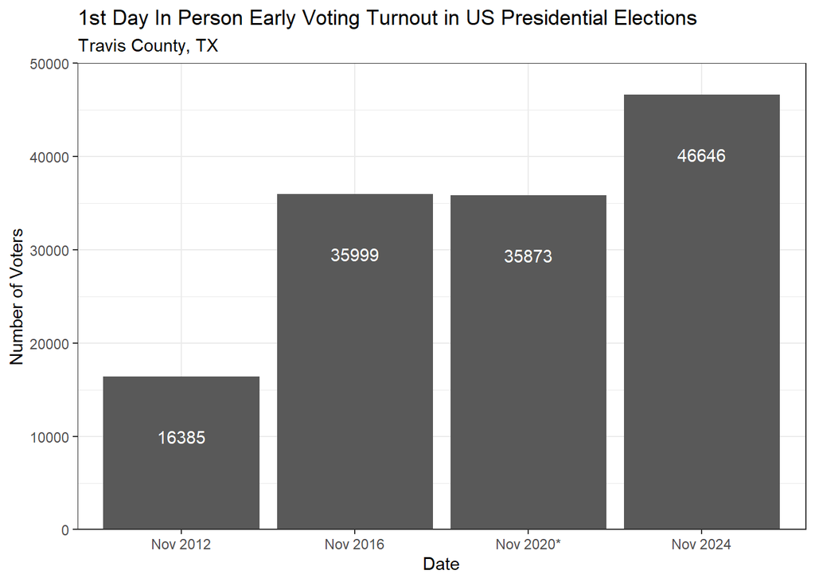

```r
# replicating the dataset
df <- data.frame(
  Date = c("Nov 2024", "Nov 2020*", "Nov 2016", "Nov 2012"),
  Turnout = c(46646, 35873, 35999, 16385))

# creating the chart
df %>%
  ggplot(aes(x = Date, y = Turnout)) +
  geom_col() +
  geom_text(aes(label = Turnout), vjust = 5, colour = "white") +
  labs(title = "1st Day In Person Early Voting Turnout in US Presidential Elections",
       subtitle = "Travis County, TX",
       y = "Number of Voters") +
  theme(plot.title = element_text(size = 14, face = "bold")) +
  theme_bw() +
  scale_y_continuous(limits = c(0,50000), expand = c(0,0))
```

The above chart is better than the original because:  
- the columns are the correct heights (ie. they correspond with labeling on the Y axis, and the height proportion between columns is correct)  
- the columns are ordered chronologically, which is more intuitive  
- the colors do not imply that the chart has anything to do with party alignment.